# Practicals 9: Machine learning

BE_22 Bioinformatics SS 23

January Weiner

2023-06-22

# Prerequisites

Please install the following packages:

```r
install.packages(c("randomForest", "party", "MASS", "pROC"))
```

Please load the following three data sets:

```r
m_dat      <- read.csv("https://january3.github.io/Bioinformatics/Datasets/metabo_data.csv",
                       row.names=1)
m_samples  <- read.csv("https://january3.github.io/Bioinformatics/Datasets/metabo_coldata.csv",
                       row.names=1)
m_features <- read.csv("https://january3.github.io/Bioinformatics/Datasets/metabo_fdata.csv",
                       row.names=1)
```

# Machine learning algorithms

There are numerous machine learning algorithms:

- decision trees
  - with bagging
  - with boosting
  - random forests
- support vector machines (SVMs)
- projections to latent structures (PLS)
- linear discriminant analysis
- regression models (e.g. logistic regression, ridge regression, lasso regression, elastic nets)
- neuronal networks
- deep learning algorithms

Today, we will first apply LDA to the iris data set, and then we will apply decision trees to a metabolome data set.

# Iris data set

## Creating a training and test set

```r
data(iris)
n <- nrow(iris) # 150
train <- sample(1:n, size=2/3 * n)
test  <- setdiff(1:n, train)

iris_train <- iris[train, ]
iris_test  <- iris[test,  ]
```

**Exercise. (5 min)** Make sure that you understand *exactly* what is happening above. Ask questions if necessary. How many samples are in the training set? How many in the test set? How many of each species is in the test set? Are the group sizes balanced? (what does “balanced” mean?)

## LDA with the iris data set

First, we create a model for discriminating between versicolor and virginica iris species only.

```r
data(iris)
library(MASS)
library(tidyverse)
iris_train_vv <- iris_train %>% filter(Species != "setosa") %>%
  mutate(Species=factor(Species))
mod_lda_vv <- lda(Species ~ ., data=iris_train_vv)
```

The result is an object of class `lda`, which is a list. The element `scaling` (`mod_lda_vv$scaling`) contains a matrix with the coefficients for each of the four features (variables). We now can calculate the values of the LD function for each of the samples. We use here the `predict` function, but we are not predicting anything – this is still the training set.

```r
iris_train_vv_pred <- predict(mod_lda_vv, iris_train_vv)
iris_train_vv_pred <- iris_train_vv_pred$x[,1]
```

The element `x` of the object returned by `predict` is a matrix with one column containing the LD values. We can visualize the data with a boxplot:

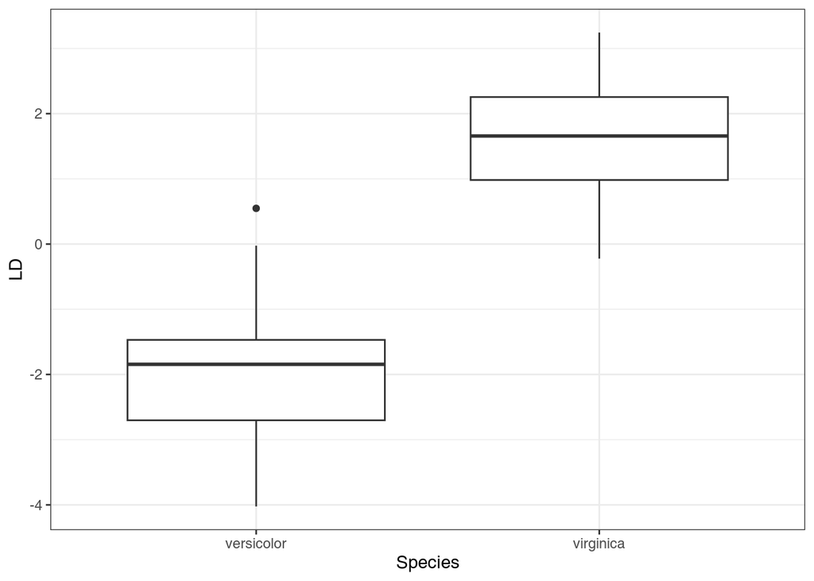

```r
df <- data.frame(Species=iris_train_vv$Species, LD=iris_train_vv_pred)
ggplot(df, aes(x=Species, y=LD)) + geom_boxplot()
```

We see that LD is high for *virginica* and low for *versicolor*.

**Exercise (5min)**. The coefficients for Sepals in the LD are negative, while the coefficients for Petals are positive. LD is positive for *virginica* and negative for *versicolor*. Question: based on this fact, are petals larger in *virginica* or in *versicolor*?

## Making and testing predictions

We can now make predictions for the test set:

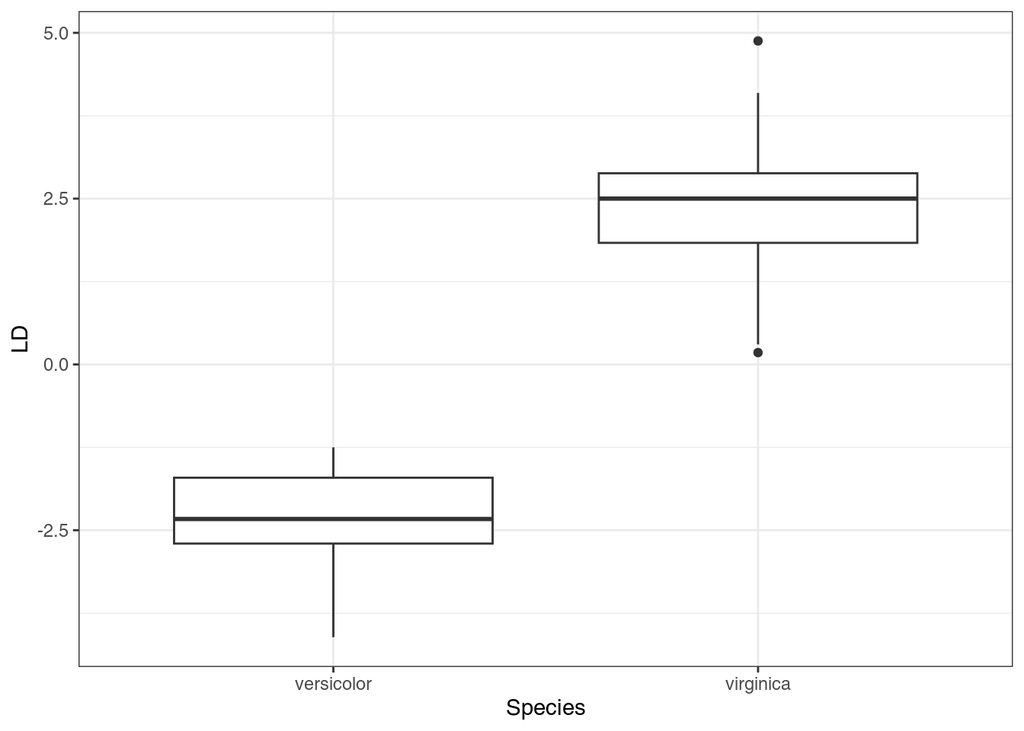

```r
iris_test_vv <- iris_test %>% filter(Species != "setosa") %>%
  mutate(Species=factor(Species))
iris_test_vv_pred <- predict(mod_lda_vv, iris_test_vv)
iris_test_vv_pred <- iris_test_vv_pred$x[,1]
df <- cbind(iris_test_vv, LD=iris_test_vv_pred)
ggplot(df, aes(x=Species, y=LD)) + geom_boxplot()
```

A natural cutoff seems to be for $LD = 0$. We now will confront the predictions with reality.

```r
pred <- ifelse(iris_test_vv_pred > 0, "virginica", "versicolor")
table(pred, iris_test_vv$Species)
```

```
##
## pred         versicolor virginica
##   versicolor         18         0
##   virginica           0        14
```

**Question.** What is the overall error rate?

**Homework 6, alternative 1**. Repeat the above analysis with the full iris data set (three classes). You will find that the `x` part of the prediction object has now two columns, `LD1` and `LD2`. Make boxplots for both of them. Which LD discriminates between which species? [note: instead of this homework, you are allowed to choose the “alternative 2” (only if we don’t do it together during practicals) and “alternative 3” below] Submit an Rmarkdown file.

# The metabo data set

The metabo data set contains metabolomic profiles for patients suffering from tuberculosis (TB) and of two classes of healthy controls: LTBI, that is individuals who are healthy, but infected with *Mycobacterium tuberculosis*, and CTRL, who are healthy and uninfected.

The data set consists of three data frames (which we loaded in the “Prerequisites” section).

**Exercise (5m).** Inspect the data files and tell me what they are.

First, we will remove all biochemicals without a known name:

```r
sel <- !grepl("^X-[0-9]*$", m_features$BIOCHEMICAL.NAME)
m_features <- m_features[sel, ]
m_dat <- m_dat[sel, ]
```

We will need a data frame containing the features in columns rather than rows (we use GROUP2 for classification because it only has two classes):

```r
m_df <- data.frame(GROUP=factor(m_samples$GROUP2), t(m_dat))
```

Here is a PCA plot of the data:

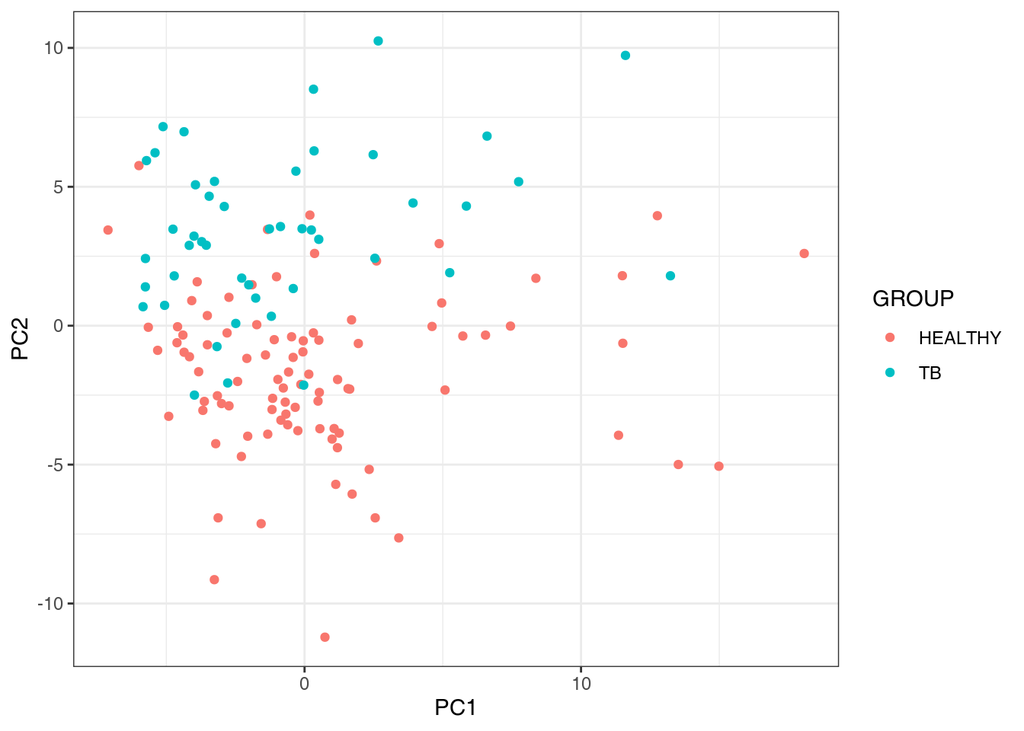

```r
pca <- prcomp(t(m_dat), scale.=TRUE)
df <- data.frame(GROUP=m_samples$GROUP2, pca$x[,1:5])
ggplot(df, aes(x=PC1, y=PC2, color=GROUP)) + geom_point()
```

As before, we will create a training and test set selection.

```r
set.seed(12345678)
n <- nrow(m_samples) # number of samples
train <- sample(1:n, size=2/3 * n)
test  <- setdiff(1:n, train)
```

In the following, we will be creating various ML models for the data and test their performance.

## Decision trees

To understand a decision tree it is best to just visualize it:

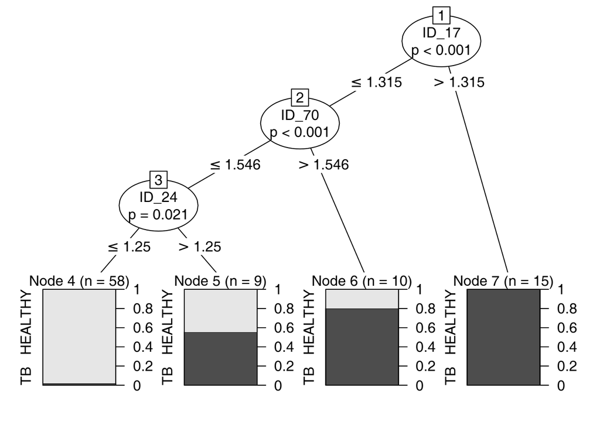

```r
library(party)

ct <- ctree(GROUP ~ ., data=m_df[ train, ])
plot(ct)
```

We will now discuss what is on that tree.

**Exercise. (5min)** What are the biochemicals which were selected by the algorithm?

Now we can apply the model of the tree to the test data set:

```r
preds <- predict(ct, newdata=m_df[ test, ])
tmp <- table(preds, m_df[ test, ]$GROUP)
print(tmp)
```

```
##
## preds     HEALTHY TB
##   HEALTHY      21  5
##   TB            8 12
```

Remember: columns correspond to the reality and rows to the predictions. Therefore, we interpret the numbers as follows:

| Abbr | Name | Description | Count |
| --- | --- | --- | --- |
| TN | true negative | prediction: HEALTHY, reality: HEALTHY | 21 |
| FP | false positive | prediction: TB, reality: HEALTHY | 8 |
| FN | false negative | prediction: HEALTHY, reality: TB | 5 |
| TP | true positive | prediction: TB, reality: TB | 12 |

**Exercise. (15’)** Calculate the sensitivity, specificity, FPR and FDR. Consult [Wikipedia](https://en.wikipedia.org/wiki/Sensitivity_and_specificity) if necessary, specifically the frame on the right hand side.

## Running a leave-one-out crossvalidation (LOO-CV)

LOO-CV allows us to take advantage of almost all samples in the data set when constructing a model, while avoiding overfitting.

The package `caret` contains many useful features for modeling and cross-validation, however (i) it will be useful to see how LOO-CV works under the hood and (ii) the package is not very straightforward to use. Therefore, we will use our own code. With R vectorization it is quite simple, really:

```r
test_one <- function(df, i) {
  train <- df[-i, ]
  test  <- df[ i, ]
  ct <- ctree(GROUP ~ ., train)
  pred <- as.character(predict(ct, newdata=test))
  return(pred)
}

## warning! This takes a while
preds <- map_chr(1:nrow(m_df), ~ test_one(m_df, .x))
```

This results in the following performance:

|  | HEALTHY | TB |
| --- | --- | --- |
| **HEALTHY** | 84 | 7 |
| **TB** | 8 | 39 |

## Random forests

One of the ways to improve the predictions from a decision tree is to combine bootstrapping (using only parts of the data) with growing multiple trees, each tree making its own decision. The grown “forest” of the trees then casts a vote regarding a sample, and the majority wins.

One of the great advantages of random forests is that it delivers out-of-bag (OOB) estimates which are nearly as good as the ones that you get when doing cross-validation. This is why we are allowed to work here with the full data set rather than with the training set.

```r
library(randomForest)
rf <- randomForest(GROUP ~ ., data=m_df, importance=TRUE)
print(rf)
```

```
##
## Call:
##  randomForest(formula = GROUP ~ ., data = m_df, importance = TRUE)
##                Type of random forest: classification
##                      Number of trees: 500
## No. of variables tried at each split: 13
##
##         OOB estimate of  error rate: 6.52%
## Confusion matrix:
##         HEALTHY TB class.error
## HEALTHY      91  1  0.01086957
## TB            8 38  0.17391304
```

We now can check what would happen if we actually tested the model using the data set that we used to train it:

```r
### INCORRECT!!!
preds <- predict(rf, m_df)
table(preds, m_df$GROUP)
```

```
##
## preds     HEALTHY TB
##   HEALTHY      92  0
##   TB            0 46
```

The above is *vastly* overfit – no errors at al! But this will not work like that in a new data set.

### Variable importance

We cannot check individual trees (well, we can, but its complicated) to see which metabolites play a role in the classification, but we can ask what variables are most important *overall*:

```r
imp <- rf$importance %>% as.data.frame %>%
  arrange(-MeanDecreaseAccuracy) %>% head(20)

merge(m_features, imp, by.x="ID", by.y=0) %>%
  dplyr::select(ID, BIOCHEMICAL.NAME, SUB.PATHWAY, HEALTHY, TB,
         MeanDecreaseAccuracy) %>% knitr::kable()
```

| ID | BIOCHEMICAL.NAME | SUB.PATHWAY | HEALTHY | TB | MeanDecreaseAccuracy |
| --- | --- | --- | --- | --- | --- |
| ID_12 | pyroglutamine* | Glutamate metabolism | 0.0045641 | 0.0165807 | 0.0083925 |
| ID_121 | 3-carboxy-4-methyl-5-propyl-2-furanpropanoate (CMPF) | Fatty acid, furan, dicarboxylate | 0.0050517 | 0.0084333 | 0.0061574 |
| ID_139 | 1-myristoylglycerophosphocholine* (C14:0) | Glycerolipid metabolism | 0.0033308 | 0.0064863 | 0.0043195 |
| ID_159 | taurochenodeoxycholate | Bile acid metabolism | 0.0016939 | 0.0038122 | 0.0024404 |
| ID_169 | cortisol | Sterol/Steroid | 0.0036034 | 0.0091002 | 0.0053039 |
| ID_17 | phenylalanine | Phenylalanine & tyrosine metabolism | 0.0103507 | 0.0130885 | 0.0112540 |
| ID_171 | citrate | Krebs cycle | 0.0036999 | 0.0110992 | 0.0058717 |
| ID_24 | kynurenine | Tryptophan metabolism | 0.0060844 | 0.0064443 | 0.0061928 |
| ID_35 | beta-hydroxyisovalerate | Valine, leucine and isoleucine metabolism | 0.0039891 | 0.0035924 | 0.0038450 |
| ID_4 | threonine | Glycine, serine and threonine metabolism | 0.0016321 | 0.0162220 | 0.0063656 |
| ID_41 | cysteine | Cysteine, methionine, SAM, taurine metabolism | 0.0153378 | 0.0286705 | 0.0199347 |
| ID_49 | citrulline | Urea cycle; arginine-, proline-, metabolism | 0.0104126 | 0.0197633 | 0.0133568 |
| ID_51 | trans-4-hydroxyproline | Urea cycle; arginine-, proline-, metabolism | 0.0021058 | 0.0056389 | 0.0032808 |
| ID_54 | creatine | Creatine metabolism | 0.0041838 | 0.0102168 | 0.0060958 |
| ID_59 | cysteine-glutathione disulfide | Glutathione metabolism | 0.0036727 | 0.0117810 | 0.0064059 |
| ID_70 | ADSGEGDFXAEGGGVR* (fibrinopeptide) | Polypeptide | 0.0057186 | 0.0110439 | 0.0073084 |
| ID_71 | DSGEGDFXAEGGGVR* (fibrinopeptide) | Polypeptide | 0.0028706 | 0.0033082 | 0.0029334 |
| ID_73 | HWESASXX* (complement C3 peptide) | Polypeptide | 0.0036394 | 0.0038200 | 0.0038241 |
| ID_75 | N-acetylneuraminate | Aminosugars metabolism | 0.0078936 | 0.0186283 | 0.0112736 |
| ID_77 | mannose | Fructose, mannose, galactose, starch, and sucrose metabolism | 0.0166245 | 0.0266204 | 0.0197107 |

Fine, but does that make sense? Let us plot some of the molecules.

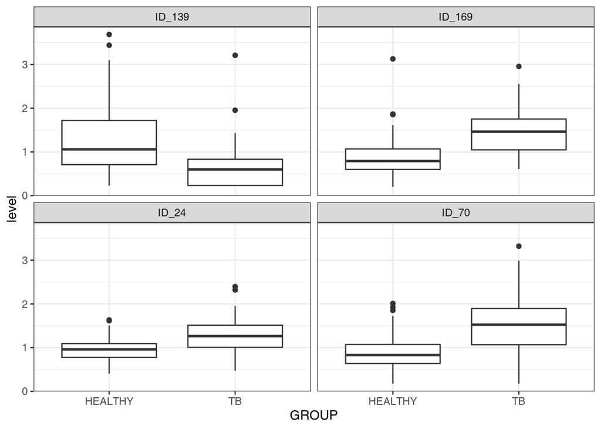

```r
sel <- c("ID_24", "ID_169", "ID_70", "ID_139")
df <- m_df %>% dplyr::select(all_of(c("GROUP", sel))) %>%
  pivot_longer(starts_with("ID"), names_to="ID", values_to="level")
ggplot(df, aes(x=GROUP, y=level))+   geom_boxplot() +
  facet_wrap(~ ID, ncol=2)
```

## ROC curves

To plot a ROC curve, we need a numeric predictor and not binary (yes / no) predictions. To get these numeric predictor, we can use `predict` with option `prob=TRUE` (this works for other algorithms as well!). *However* we cannot do that for random forest: predictions would be overfit! We need the *OOB* estimates of the probabilities. These are stored in the rf object:

```r
probs <- rf$votes
head(probs)
```

```
##              HEALTHY         TB
## MPIB_00173 0.7526882 0.24731183
## MPIB_00174 0.9365079 0.06349206
## MPIB_00175 0.8500000 0.15000000
## MPIB_00176 0.9142857 0.08571429
## MPIB_00177 0.8743169 0.12568306
## MPIB_00178 0.8655914 0.13440860
```

The two columns indicate the percentage of votes each class got from the trees, so `0.124` in column “HEALTHY” indicates that 12% of the trees decided that this given sample comes from a healthy person (and 88% trees decided that this is a TB patient).

```r
probs_df <- as.data.frame(probs) %>% merge(m_samples, by.x=0, by.y="SAMPLE_NAME") %>% arrange(HEALTHY)
head(probs_df)
```

```
##    Row.names   HEALTHY        TB GENDER GROUP1 GROUP2
## 1 MPIB_00308 0.1032609 0.8967391      M     TB     TB
## 2 MPIB_00290 0.1473684 0.8526316      F     TB     TB
## 3 MPIB_00277 0.1505376 0.8494624      F     TB     TB
## 4 MPIB_00301 0.1587302 0.8412698      M     TB     TB
## 5 MPIB_00304 0.1739130 0.8260870      M     TB     TB
## 6 MPIB_00285 0.1746032 0.8253968      F     TB     TB
```

To plot a ROC curve, we use `roc` from package `pROC`. We need to supply the `levels` argument to tell pROC which one is the positive and which one is the negative:

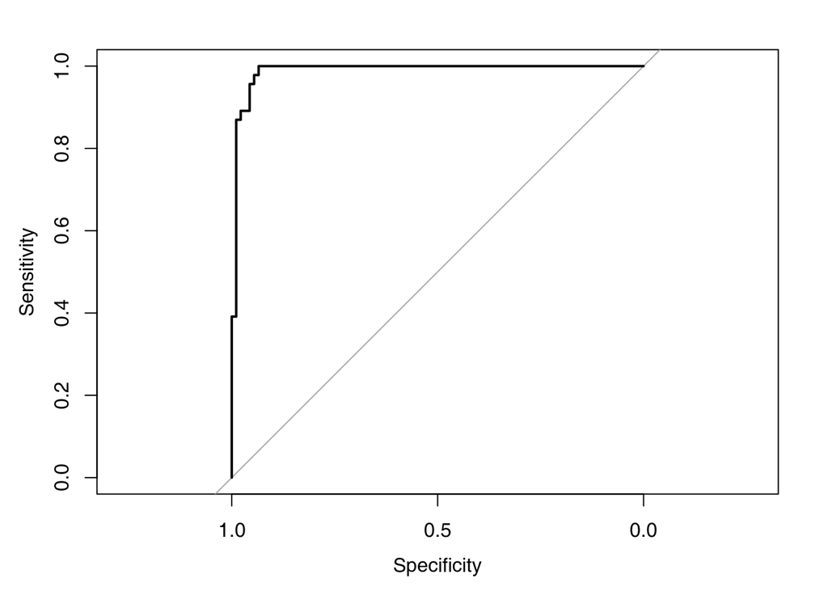

```
##
## Call:
## roc.default(response = m_df$GROUP, predictor = probs[, 1], levels = c("HEALTHY",     "TB"), plot = TRUE)
##
## Data: probs[, 1] in 92 controls (m_df$GROUP HEALTHY) > 46 cases (m_df$GROUP TB).
## Area under the curve: 0.9889
```

```r
library(pROC)
roc(response=m_df$GROUP, predictor=probs[,1],
    levels=c("HEALTHY", "TB"), plot=TRUE)
```

We can also calculate the area under the curve (AUC) and its confidence intervals:

```r
roc(response=m_df$GROUP, predictor=probs[,1],
    levels=c("HEALTHY", "TB"), ci=TRUE)
```

```
##
## Call:
## roc.default(response = m_df$GROUP, predictor = probs[, 1], levels = c("HEALTHY",     "TB"), ci = TRUE)
##
## Data: probs[, 1] in 92 controls (m_df$GROUP HEALTHY) > 46 cases (m_df$GROUP TB).
## Area under the curve: 0.9889
## 95% CI: 0.9746-1 (DeLong)
```

We can compare it with a roc curve from the decision tree model. However, for this we need a slight modification of our LOO-CV function:

```r
test_one <- function(df, i) {
  train <- df[-i, ]
  test  <- df[ i, ]
  ct <- ctree(GROUP ~ ., train)
  pred <- predict(ct, newdata=test, type="prob")[[1]][1]
  return(pred)
}

## warning! This takes a while
ct_probs <- map_dbl(1:nrow(m_df), ~ test_one(m_df, .x))
```

And plot the ROC curve:

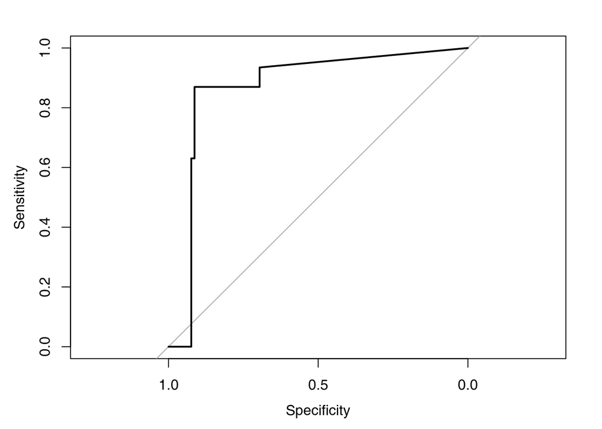

```
##
## Call:
## roc.default(response = m_df$GROUP, predictor = ct_probs, levels = c("HEALTHY",     "TB"), plot = TRUE)
##
## Data: ct_probs in 92 controls (m_df$GROUP HEALTHY) > 46 cases (m_df$GROUP TB).
## Area under the curve: 0.8689
```

```r
roc(response=m_df$GROUP, predictor=ct_probs,
    plot=TRUE,
    levels=c("HEALTHY", "TB"))
```

**Homework 6, alternative 3**. Another method of machine learning are the Support Vector Machines (learn more [here](https://www.datacamp.com/community/tutorials/support-vector-machines-r)). An SVM algorithm is implemented in the function `svm` of the package `e1071`. Train `svm` on the metabolomic training data set, test it on the testing data set (using `predict`), calculate the sensitivity and specificity. Submit an Rmarkdown file.